# **AI Global Trade Platform - Final Report**

## **Introduction**

- This project analyzes U.S. and international trade data, focusing on Ohio’s export trends and socioeconomic factors across U.S. states. Using data from the U.S. Census, UN Comtrade, and OECD, the goal is to uncover insights that can support AI-driven trade strategies. This report summarizes key findings and suggests ideas for applying AI and data analytics to real-world trade challenges.

### **Data Sources**

- U.S. Census Bureau APIs.
- UN Comtrade Database
- OECD Data Explorer

### **Key Insights:**

- Population is not a reliable indicator of market wealth. Our analysis shows no strong correlation between a state’s population and its median household income. Instead, factors like higher education and low poverty rates are much stronger predictors of economic health.
- Ohio’s export landscape is shifting. While traditional sectors like vehicles and electronics saw a decline, high-value, specialized industries such as aerospace and defense parts showed significant growth, pointing to a strategic opportunity.
- Global trade is dominated by a few key players. The USA and China are the world’s largest importers by a significant margin. For U.S. exporters, machinery and electrical equipment remain the most valuable sectors, with China being a primary market.

## **U.S. Census Bureau**

### **Section 1: Should I target states with the highest population to expand my business?**

```r
library(tidycensus)
library(tidyverse)
library(httr)
library(jsonlite)
library(dplyr)
```

##### **Set and Store Census API Key**

```r
census_api_key("d095e857a825a48930b9bd7954af22da0202201b", install = "TRUE", overwrite = TRUE)
```

```
## Your original .Renviron will be backed up and stored in your R HOME directory if needed.
```

```
## Your API key has been stored in your .Renviron and can be accessed by Sys.getenv("CENSUS_API_KEY").
## To use now, restart R or run `readRenviron("~/.Renviron")`
```

```
## [1] "d095e857a825a48930b9bd7954af22da0202201b"
```

##### **1) Retrieve 2020 Population Data by State**

```r
vintage <- 2020
Population_data <- get_decennial(geography = "state", variables = "P1_001N", year = vintage)
```

```
## Using the PL 94-171 Redistricting Data Summary File
```

```
## Note: 2020 decennial Census data use differential privacy, a technique that
## introduces errors into data to preserve respondent confidentiality.
## ℹ Small counts should be interpreted with caution.
## ℹ See https://www.census.gov/library/fact-sheets/2021/protecting-the-confidentiality-of-the-2020-census-redistricting-data.html for additional guidance.
```

```r
knitr::kable(Population_data)
```

| GEOID | NAME | variable | value |
| --- | --- | --- | --- |
| 42 | Pennsylvania | P1_001N | 13002700 |
| 06 | California | P1_001N | 39538223 |
| 54 | West Virginia | P1_001N | 1793716 |
| 49 | Utah | P1_001N | 3271616 |
| 36 | New York | P1_001N | 20201249 |
| 11 | District of Columbia | P1_001N | 689545 |
| 02 | Alaska | P1_001N | 733391 |
| 12 | Florida | P1_001N | 21538187 |
| 45 | South Carolina | P1_001N | 5118425 |
| 38 | North Dakota | P1_001N | 779094 |
| 23 | Maine | P1_001N | 1362359 |
| 13 | Georgia | P1_001N | 10711908 |
| 01 | Alabama | P1_001N | 5024279 |
| 33 | New Hampshire | P1_001N | 1377529 |
| 41 | Oregon | P1_001N | 4237256 |
| 56 | Wyoming | P1_001N | 576851 |
| 04 | Arizona | P1_001N | 7151502 |
| 22 | Louisiana | P1_001N | 4657757 |
| 18 | Indiana | P1_001N | 6785528 |
| 16 | Idaho | P1_001N | 1839106 |
| 09 | Connecticut | P1_001N | 3605944 |
| 15 | Hawaii | P1_001N | 1455271 |
| 17 | Illinois | P1_001N | 12812508 |
| 25 | Massachusetts | P1_001N | 7029917 |
| 48 | Texas | P1_001N | 29145505 |
| 30 | Montana | P1_001N | 1084225 |
| 31 | Nebraska | P1_001N | 1961504 |
| 39 | Ohio | P1_001N | 11799448 |
| 08 | Colorado | P1_001N | 5773714 |
| 34 | New Jersey | P1_001N | 9288994 |
| 24 | Maryland | P1_001N | 6177224 |
| 51 | Virginia | P1_001N | 8631393 |
| 50 | Vermont | P1_001N | 643077 |
| 37 | North Carolina | P1_001N | 10439388 |
| 05 | Arkansas | P1_001N | 3011524 |
| 53 | Washington | P1_001N | 7705281 |
| 20 | Kansas | P1_001N | 2937880 |
| 40 | Oklahoma | P1_001N | 3959353 |
| 55 | Wisconsin | P1_001N | 5893718 |
| 28 | Mississippi | P1_001N | 2961279 |
| 29 | Missouri | P1_001N | 6154913 |
| 26 | Michigan | P1_001N | 10077331 |
| 44 | Rhode Island | P1_001N | 1097379 |
| 27 | Minnesota | P1_001N | 5706494 |
| 19 | Iowa | P1_001N | 3190369 |
| 35 | New Mexico | P1_001N | 2117522 |
| 32 | Nevada | P1_001N | 3104614 |
| 10 | Delaware | P1_001N | 989948 |
| 72 | Puerto Rico | P1_001N | 3285874 |
| 21 | Kentucky | P1_001N | 4505836 |
| 46 | South Dakota | P1_001N | 886667 |
| 47 | Tennessee | P1_001N | 6910840 |

##### **2) Visualize Population by State (Bar Chart)**

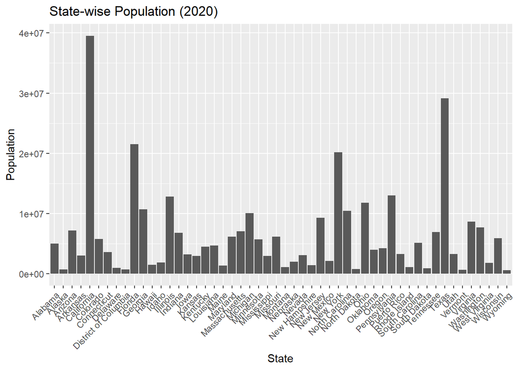

```r
library(ggplot2)

ggplot(Population_data, aes(x = NAME, y = value)) +
  geom_bar(stat = "identity") +
  theme(axis.text.x = element_text(angle = 45, hjust = 1)) +  # Rotate labels
  labs(x = "State", y = "Population", title = "State-wise Population (2020)")
```

### **Obseravation:**

- California stands out with the highest population, followed by Texas, Florida, and New York.
- States like Wyoming, Vermont, Alaska, and North Dakota have the smallest populations.
- The chart helps visually compare state populations, showing a large gap between the most and least populated states.

##### **Fetch Additional 2020 Demographics**

```r
variables <- c("P1_001N", "P1_003N")
extra_demographics <- get_decennial(geography = "state", variables = variables, year = vintage)
```

```
## Using the PL 94-171 Redistricting Data Summary File
```

```r
trend_data <- get_acs(geography = "state", variables = "B01003_001", years = c(2010:2020))
```

##### **3) U.S. Population Choropleth Map (2020)**

```r
library(tigris)
library(sf)
states_sf <- states(cb = TRUE)
```

[output not shown]

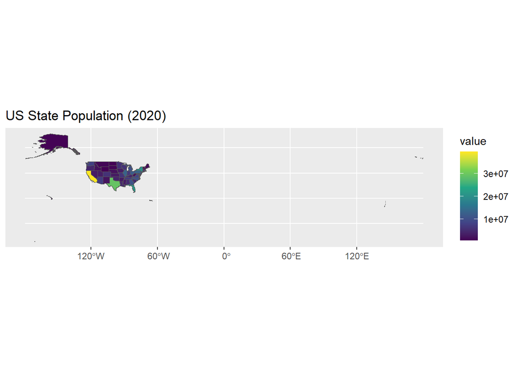

```r
pop_joined <- left_join(states_sf, Population_data, by = c("NAME" = "NAME"))
ggplot(pop_joined) +
  geom_sf(aes(fill = value)) +
  scale_fill_viridis_c() +
  labs(title = "US State Population (2020)")
```

##### **4) Top 5 States by Population Table**

```r
library(knitr)

Population_data %>%
  arrange(desc(value)) %>%
  head(5) %>%
  kable(caption = "Top 5 States by Population")
```

Top 5 States by Population

| GEOID | NAME | variable | value |
| --- | --- | --- | --- |
| 06 | California | P1_001N | 39538223 |
| 48 | Texas | P1_001N | 29145505 |
| 12 | Florida | P1_001N | 21538187 |
| 36 | New York | P1_001N | 20201249 |
| 42 | Pennsylvania | P1_001N | 13002700 |

### **Observation:**

- From this table, we see that California, Texas, Florida, New York, and Pennsylvania had the largest populations, with California having the highest at nearly 39.5 million.

### **Section 2: Where is the highest purchasing power located in the U.S.?**

##### **Get Median Household Income by State (2020)**

```r
income_data <- get_acs(geography = "state", variables = "B19013_001", year = 2020)
merged <- left_join(Population_data, income_data, by = "NAME")
```

##### **1) Bar plot of median household income by state**

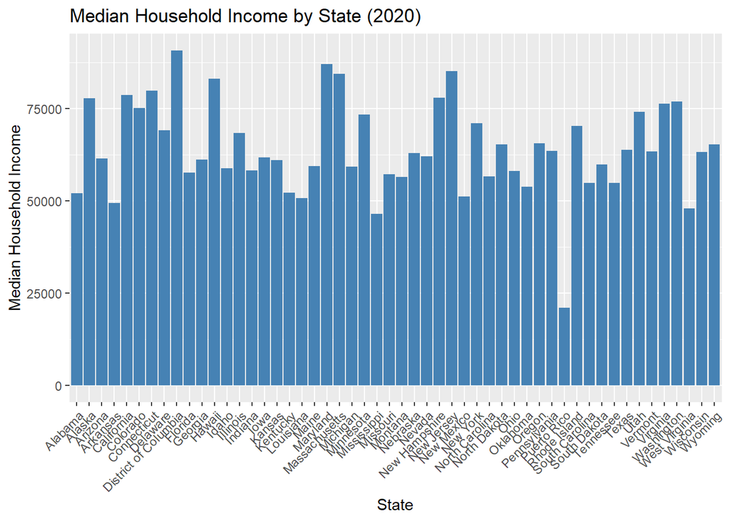

```r
library(ggplot2)
ggplot(merged, aes(x = NAME, y = estimate)) +
  geom_bar(stat = "identity", fill = "steelblue") +
  theme(axis.text.x = element_text(angle = 45, hjust = 1)) +
  labs(x = "State", y = "Median Household Income", title = "Median Household Income by State (2020)")
```

### **Section 3: Is there a direct link between a state’s population and its wealth?**

##### **1) Population vs. Median Income by State (2020)**

```r
library(ggrepel)
```

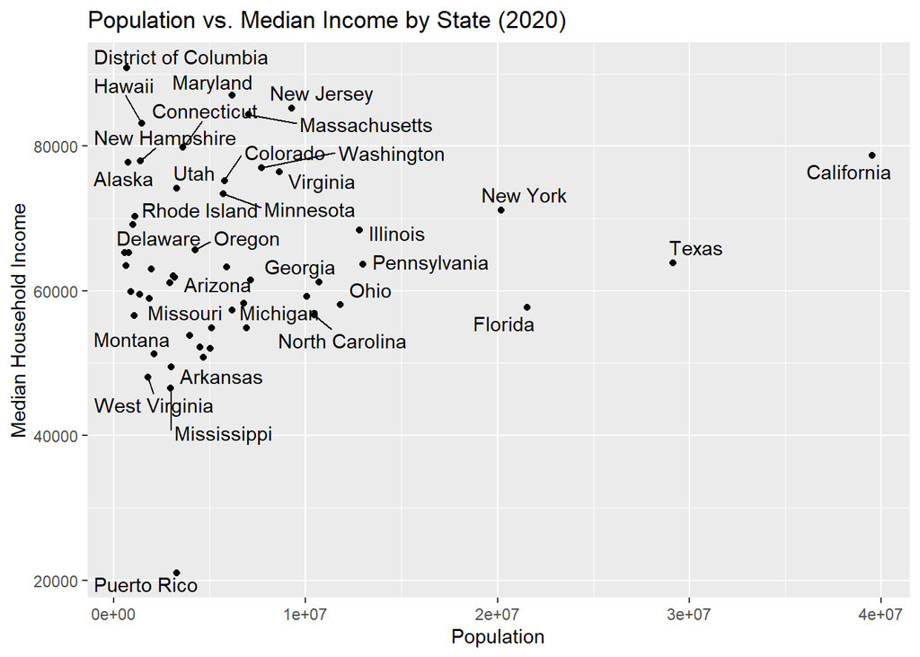

```r
ggplot(merged, aes(x = value, y = estimate, label = NAME)) +
  geom_point() +
  geom_text_repel() +
  labs(
    x = "Population",
    y = "Median Household Income",
    title = "Population vs. Median Income by State (2020)"
  )
```

### **Observation:**

##### **Lowest to highest based on median household income**

##### **2) Top 5 states by income**

```r
# Top 5 states by income
merged %>%
  arrange(desc(estimate)) %>%
  head(5) %>%
  rename(State = NAME, Median_Income = estimate) %>%
  kable(caption = "Top 5 States by Median Household Income")
```

Top 5 States by Median Household Income

| GEOID.x | State | variable.x | value | GEOID.y | variable.y | Median_Income | moe |
| --- | --- | --- | --- | --- | --- | --- | --- |
| 11 | District of Columbia | P1_001N | 689545 | 11 | B19013_001 | 90842 | 1580 |
| 24 | Maryland | P1_001N | 6177224 | 24 | B19013_001 | 87063 | 391 |
| 34 | New Jersey | P1_001N | 9288994 | 34 | B19013_001 | 85245 | 402 |
| 25 | Massachusetts | P1_001N | 7029917 | 25 | B19013_001 | 84385 | 511 |
| 15 | Hawaii | P1_001N | 1455271 | 15 | B19013_001 | 83173 | 983 |

### **Observation**

- DC has the highest median income ($90,842) but the smallest population (~690K).
- Maryland shows high income ($87,063) with a large population (~6.2M) and the lowest margin of error ($391), making its estimate more reliable.
- New Jersey has the largest population (~9.3M) and a strong income level ($85,245).
- Massachusetts and Hawaii follow closely with high median incomes ($84,385 and $83,173).
- All regions listed are high-income states compared to the national average.

##### **3) Bottom 5 states by income**

```r
merged %>%
  arrange(estimate) %>%
  head(5) %>%
  rename(State = NAME, Median_Income = estimate) %>%
  kable(caption = "Bottom 5 States by Median Household Income")
```

Bottom 5 States by Median Household Income

| GEOID.x | State | variable.x | value | GEOID.y | variable.y | Median_Income | moe |
| --- | --- | --- | --- | --- | --- | --- | --- |
| 72 | Puerto Rico | P1_001N | 3285874 | 72 | B19013_001 | 21058 | 186 |
| 28 | Mississippi | P1_001N | 2961279 | 28 | B19013_001 | 46511 | 373 |
| 54 | West Virginia | P1_001N | 1793716 | 54 | B19013_001 | 48037 | 616 |
| 05 | Arkansas | P1_001N | 3011524 | 05 | B19013_001 | 49475 | 431 |
| 22 | Louisiana | P1_001N | 4657757 | 22 | B19013_001 | 50800 | 360 |

### **Observation**:

- Puerto Rico has the lowest median income at $21,058, with a population of ~3.3M.
- Mississippi is the lowest among U.S. states at $46,511.
- West Virginia and Arkansas follow with incomes around $48K–$49K.
- Louisiana has the highest income among the bottom five at $50,800.
- These states represent economically struggling regions with incomes well below the national average.

##### **4) Map Income Data**

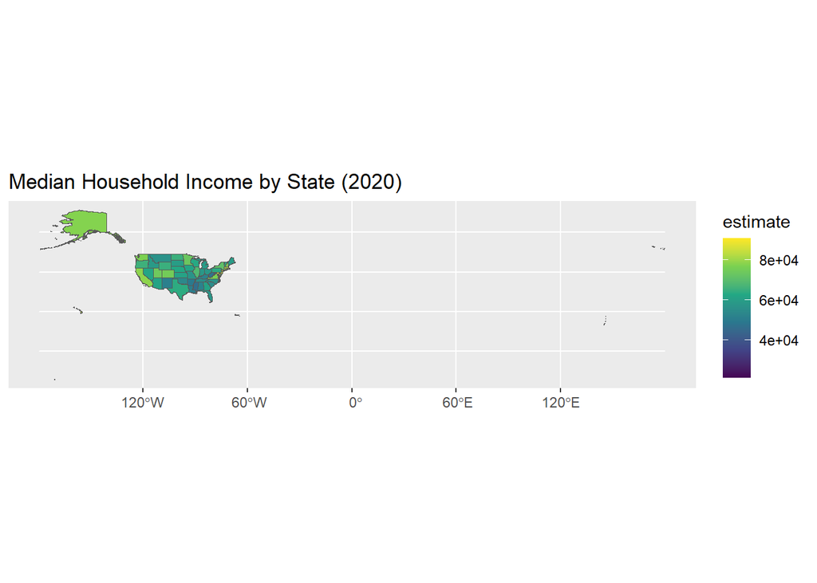

```r
# Join income data to state map and plot
income_map <- left_join(states_sf, income_data, by = c("NAME" = "NAME"))
ggplot(income_map) +
  geom_sf(aes(fill = estimate)) +
  scale_fill_viridis_c() +
  labs(title = "Median Household Income by State (2020)")
```

### **Observation:**

- Puerto Rico has the lowest median household income in the country.
- Mississippi, West Virginia, Arkansas, and Louisiana also have very low income levels.
- Most of these states are located in the southern United States or are U.S. territories.

### **Section 4: What underlying factors drive a state’s economic health?**

##### **Extracting Education, Unemployment, Poverty, manufacturing**

```r
# 1) Education count (bachelor’s degree or higher)
edu_data <- get_acs(geography = "state",
                    variables = "B15003_022",
                    year = 2020) %>%
  select(NAME, edu_count = estimate)
# 2) Unemployment count
unemp_data <- get_acs(geography = "state",
                      variables = "B23025_005",
                      year = 2020) %>%
  select(NAME, unemp_count = estimate)
# 3) Poverty count
poverty_data <- get_acs(geography = "state",
                        variables = "B17001_002",
                        year = 2020) %>%
  select(NAME, poverty_count = estimate)
# 4) Manufacturing employment count
industry_data <- get_acs(geography = "state",
                         variables = "C24050_002",
                         year = 2020) %>%
  select(NAME, industry_count = estimate)
```

##### **Retrieving Denominator Populations for Socioeconomic Rate Calculations by State**

```r
edu_denom <- get_acs(geography = "state",
                     variables = "B15003_001",
                     year = 2020) %>%
  select(NAME, edu_pop_25plus = estimate)
labor_force <- get_acs(geography = "state",
                       variables = "B23025_003",
                       year = 2020) %>%
  select(NAME, labor_force_pop = estimate)
poverty_denom <- get_acs(geography = "state",
                         variables = "B17001_001",
                         year = 2020) %>%
  select(NAME, poverty_pop = estimate)
industry_denom <- get_acs(geography = "state",
                          variables = "C24050_001",
                          year = 2020) %>%
  select(NAME, employed_pop = estimate)
merged <- Population_data %>%
  left_join(edu_data,        by = "NAME") %>%
  left_join(unemp_data,      by = "NAME") %>%
  left_join(poverty_data,    by = "NAME") %>%
  left_join(industry_data,   by = "NAME") %>%
  left_join(edu_denom,       by = "NAME") %>%
  left_join(labor_force,     by = "NAME") %>%
  left_join(poverty_denom,   by = "NAME") %>%
  left_join(industry_denom,  by = "NAME")
```

##### **1) Calculating Socioeconomic Rates and Displaying as a Table by State**

```r
merged <- merged %>%
  mutate(
    edu_rate      = edu_count      / edu_pop_25plus,  # % with bachelor’s degree
    unemp_rate    = unemp_count    / labor_force_pop, # % unemployed
    poverty_rate  = poverty_count  / poverty_pop,     # % in poverty
    industry_rate = industry_count / employed_pop     # % in manufacturing
  )

table_data <- merged %>%
  select(NAME, edu_rate, unemp_rate, poverty_rate, industry_rate)

knitr::kable(table_data)
```

| NAME | edu_rate | unemp_rate | poverty_rate | industry_rate |
| --- | --- | --- | --- | --- |
| Pennsylvania | 0.1951403 | 0.0535595 | 0.1195142 | 0.0126475 |
| California | 0.2161934 | 0.0618374 | 0.1257696 | 0.0211451 |
| West Virginia | 0.1274258 | 0.0653407 | 0.1709692 | 0.0356671 |
| Utah | 0.2301003 | 0.0362462 | 0.0913461 | 0.0153802 |
| New York | 0.2091653 | 0.0570045 | 0.1357796 | 0.0057312 |
| District of Columbia | 0.2526126 | 0.0711963 | 0.1545250 | 0.0015362 |
| Alaska | 0.1865004 | 0.0718334 | 0.1033700 | 0.0448297 |
| Florida | 0.1926273 | 0.0543035 | 0.1333552 | 0.0087329 |
| South Carolina | 0.1817427 | 0.0553377 | 0.1467562 | 0.0093855 |
| North Dakota | 0.2210180 | 0.0310322 | 0.1053093 | 0.0918300 |
| Maine | 0.2033276 | 0.0403876 | 0.1107207 | 0.0244768 |
| Georgia | 0.1968593 | 0.0560397 | 0.1427544 | 0.0106864 |
| Alabama | 0.1634788 | 0.0558239 | 0.1598289 | 0.0141138 |
| New Hampshire | 0.2304600 | 0.0375365 | 0.0742080 | 0.0076018 |
| Oregon | 0.2130378 | 0.0545794 | 0.1236489 | 0.0306733 |
| Wyoming | 0.1766615 | 0.0439858 | 0.1076213 | 0.1054580 |
| Arizona | 0.1880350 | 0.0583737 | 0.1412417 | 0.0125280 |
| Louisiana | 0.1592594 | 0.0655992 | 0.1864950 | 0.0367777 |
| Indiana | 0.1726086 | 0.0473037 | 0.1291122 | 0.0121950 |
| Idaho | 0.1930355 | 0.0420999 | 0.1193728 | 0.0477004 |
| Connecticut | 0.2215402 | 0.0604203 | 0.0978259 | 0.0039684 |
| Hawaii | 0.2194640 | 0.0455494 | 0.0926268 | 0.0138097 |
| Illinois | 0.2158485 | 0.0595820 | 0.1198751 | 0.0103446 |
| Massachusetts | 0.2453524 | 0.0508648 | 0.0984513 | 0.0041651 |
| Texas | 0.1989764 | 0.0529669 | 0.1422267 | 0.0283892 |
| Montana | 0.2221120 | 0.0415438 | 0.1278121 | 0.0635947 |
| Nebraska | 0.2138177 | 0.0339303 | 0.1036766 | 0.0435589 |
| Ohio | 0.1794364 | 0.0530344 | 0.1362079 | 0.0095863 |
| Colorado | 0.2604596 | 0.0463418 | 0.0978162 | 0.0222067 |
| New Jersey | 0.2480184 | 0.0578482 | 0.0967092 | 0.0031889 |
| Maryland | 0.2179085 | 0.0516580 | 0.0901727 | 0.0050899 |
| Virginia | 0.2236095 | 0.0462626 | 0.1001394 | 0.0084587 |
| Vermont | 0.2351110 | 0.0376149 | 0.1078445 | 0.0265213 |
| North Carolina | 0.2041734 | 0.0544467 | 0.1398191 | 0.0122609 |
| Arkansas | 0.1522893 | 0.0519048 | 0.1608265 | 0.0267258 |
| Washington | 0.2276925 | 0.0489950 | 0.1018719 | 0.0247951 |
| Kansas | 0.2146162 | 0.0407584 | 0.1144226 | 0.0310067 |
| Oklahoma | 0.1716772 | 0.0509128 | 0.1527293 | 0.0434846 |
| Wisconsin | 0.2025349 | 0.0355155 | 0.1097179 | 0.0215518 |
| Mississippi | 0.1384521 | 0.0712595 | 0.1957768 | 0.0230827 |
| Missouri | 0.1844140 | 0.0451470 | 0.1300717 | 0.0168157 |
| Michigan | 0.1825469 | 0.0601517 | 0.1371047 | 0.0113340 |
| Rhode Island | 0.2103956 | 0.0551957 | 0.1158129 | 0.0050006 |
| Minnesota | 0.2417026 | 0.0380901 | 0.0933338 | 0.0207519 |
| Iowa | 0.1971852 | 0.0391936 | 0.1111303 | 0.0375067 |
| New Mexico | 0.1581822 | 0.0657510 | 0.1855126 | 0.0398946 |
| Nevada | 0.1664446 | 0.0657081 | 0.1277505 | 0.0139049 |
| Delaware | 0.1898775 | 0.0583958 | 0.1143577 | 0.0104427 |
| Puerto Rico | 0.1903222 | 0.1507351 | 0.4340749 | 0.0133381 |
| Kentucky | 0.1475977 | 0.0537661 | 0.1660686 | 0.0194304 |
| South Dakota | 0.2006053 | 0.0350968 | 0.1280877 | 0.0644338 |
| Tennessee | 0.1778439 | 0.0533466 | 0.1461676 | 0.0097375 |

### **Observation**

- States show noticeable variation in education, unemployment, poverty, and manufacturing rates.

##### **2) Listing Top 5 States by Education Rate**

```r
library(dplyr)

top5_edu <- merged %>%
  select(NAME, edu_rate, unemp_rate, poverty_rate, industry_rate) %>%
  arrange(desc(edu_rate)) %>%   # sort descending by education rate
  slice_head(n = 5)             # take top 5 rows

knitr::kable(top5_edu)
```

| NAME | edu_rate | unemp_rate | poverty_rate | industry_rate |
| --- | --- | --- | --- | --- |
| Colorado | 0.2604596 | 0.0463418 | 0.0978162 | 0.0222067 |
| District of Columbia | 0.2526126 | 0.0711963 | 0.1545250 | 0.0015362 |
| New Jersey | 0.2480184 | 0.0578482 | 0.0967092 | 0.0031889 |
| Massachusetts | 0.2453524 | 0.0508648 | 0.0984513 | 0.0041651 |
| Minnesota | 0.2417026 | 0.0380901 | 0.0933338 | 0.0207519 |

### **Observation:**

- Colorado: High education, low unemployment, and low poverty. Doing very well overall.
- District of Columbia: High education but also higher unemployment and poverty. Mixed situation.
- New Jersey: Good education, low unemployment and poverty. Doing well.
- Massachusetts: Well-educated with low joblessness and poverty. Strong economy.
- Minnesota: Good education, lowest unemployment and poverty here. Stable and balanced.

##### **Retrieving Monthly Export Values for Ohio by 6-Digit HS Commodity Code (2023)**

```r
library(httr)
library(jsonlite)

base_url <- "https://api.census.gov/data/timeseries/intltrade/exports/statehs"
params <- list(
  get = "ALL_VAL_MO",
  STATE = "39",       # Ohio
  YEAR = "2023",
  COMM_LVL = "HS6",
  key = "d095e857a825a48930b9bd7954af22da0202201b"
)

response <- GET(base_url, query = params)
raw_json <- content(response, "text")
cat(raw_json)
```

[output not shown]

## **Regression Modeling Using Census data**

## **Section 5:Can we predict a state’s median income using socioeconomic data?**

##### **Fetching and Merging State-level Median Household Income Data for Regression Modeling**

```r
income_data <- get_acs(geography = "state", variables = "B19013_001", year = 2020)
merged_income <- left_join(Population_data, income_data, by = "NAME")

names(merged)
```

```
##  [1] "GEOID"           "NAME"            "variable"        "value"
##  [5] "edu_count"       "unemp_count"     "poverty_count"   "industry_count"
##  [9] "edu_pop_25plus"  "labor_force_pop" "poverty_pop"     "employed_pop"
## [13] "edu_rate"        "unemp_rate"      "poverty_rate"    "industry_rate"
```

##### **Merging Socioeconomic Rates with Median Household Income Data**

```r
merged_clean <- merged %>%
  left_join(income_data, by = "NAME")
```

##### **Select only the state name and rename median income from ‘estimate’ in the income data**

```r
income_data <- income_data %>%
  select(NAME, median_income = estimate)
```

##### **Merge the updated median_income column into main merged data by state name**

```r
merged_clean <- merged %>%
  left_join(income_data, by = "NAME")
```

#### **Create the regression modeling dataset with all relevant predictors and outcome, excluding any rows with missing values**

```r
reg_data <- merged_clean %>%
  select(NAME, value, edu_rate, unemp_rate, poverty_rate, industry_rate, median_income) %>%
  drop_na()
```

## **Regression modeling and analysis**

##### **1. Split Data Into Training and Test Sets**

```r
set.seed(123)  # For reproducible random split
n <- nrow(reg_data)
train_idx <- sample(n, size = floor(0.8 * n))
train_data <- reg_data[train_idx, ]
test_data  <- reg_data[-train_idx, ]
```

##### **2. Build and Fit Linear Regression Model**

```r
# Fit the linear regression model using training data
model <- lm(median_income ~ value + edu_rate + unemp_rate + poverty_rate + industry_rate, data = train_data)
summary(model)  # View model summary and interpret coefficients
```

```
##
## Call:
## lm(formula = median_income ~ value + edu_rate + unemp_rate +
##     poverty_rate + industry_rate, data = train_data)
##
## Residuals:
##    Min     1Q Median     3Q    Max
##  -6560  -2234   -622   2164   8341
##
## Coefficients:
##                 Estimate Std. Error t value Pr(>|t|)
## (Intercept)    6.173e+04  1.471e+04   4.195 0.000177 ***
## value          9.675e-05  1.233e-04   0.785 0.437925
## edu_rate       1.072e+05  4.255e+04   2.520 0.016440 *
## unemp_rate     4.580e+05  8.668e+04   5.284 6.79e-06 ***
## poverty_rate  -3.370e+05  4.967e+04  -6.784 7.27e-08 ***
## industry_rate -1.612e+04  3.976e+04  -0.406 0.687558
## ---
## Signif. codes:  0 '***' 0.001 '**' 0.01 '*' 0.05 '.' 0.1 ' ' 1
##
## Residual standard error: 3895 on 35 degrees of freedom
## Multiple R-squared:  0.8819, Adjusted R-squared:  0.8651
## F-statistic: 52.29 on 5 and 35 DF,  p-value: 2.957e-15
```

### **Interpretation**:

```r
model_simple <- lm(median_income ~ edu_rate + poverty_rate, data = train_data)
summary(model_simple)
```

```
##
## Call:
## lm(formula = median_income ~ edu_rate + poverty_rate, data = train_data)
##
## Residuals:
##     Min      1Q  Median      3Q     Max
## -9191.8 -3643.8  -708.1  3127.5 11530.2
##
## Coefficients:
##              Estimate Std. Error t value Pr(>|t|)
## (Intercept)     86514      18329   4.720 3.17e-05 ***
## edu_rate        67711      55847   1.212    0.233
## poverty_rate  -285411      63903  -4.466 6.92e-05 ***
## ---
## Signif. codes:  0 '***' 0.001 '**' 0.01 '*' 0.05 '.' 0.1 ' ' 1
##
## Residual standard error: 5708 on 38 degrees of freedom
## Multiple R-squared:  0.7248, Adjusted R-squared:  0.7103
## F-statistic: 50.04 on 2 and 38 DF,  p-value: 2.259e-11
```

### **Interpretation and Observation**:

- Poverty rate is still significant (p < 0.001) and It has a strong negative impact on income.
- Education rate is not significant anymore (p = 0.233) and It might not be helpful alone in this simplified model.
- The model now explains 72% of the variance in income (R² = 0.7248), which is lower than before (was 88%).

### **Observation:**

- Full model: includes all predictors, with R² = 0.88
- Simple model: fewer predictors, R² = 0.72

##### **Compute Predictions**

```r
# Fit both models on training data
full_model <- lm(median_income ~ value + edu_rate + unemp_rate + poverty_rate + industry_rate, data = train_data)
reduced_model <- lm(median_income ~ edu_rate + poverty_rate, data = train_data)

# Predict on test set
full_pred <- predict(full_model, newdata = test_data)
reduced_pred <- predict(reduced_model, newdata = test_data)

# Compute RMSE
rmse <- function(actual, predicted) sqrt(mean((actual - predicted)^2, na.rm = TRUE))
# Compute R-squared for predictions
rsq <- function(actual, predicted) 1 - sum((actual - predicted)^2) / sum((actual - mean(actual))^2)

# Full model metrics
full_model_rmse <- rmse(test_data$median_income, full_pred)
full_model_rsq <- rsq(test_data$median_income, full_pred)

# Reduced model metrics
reduced_model_rmse <- rmse(test_data$median_income, reduced_pred)
reduced_model_rsq <- rsq(test_data$median_income, reduced_pred)

# Print results
cat("Full model RMSE:   ", round(full_model_rmse, 2), "\n")
```

```
## Full model RMSE:    8678.85
```

```r
cat("Full model R square:     ", round(full_model_rsq, 3), "\n")
```

```
## Full model R square:      0.76
```

```r
cat("Reduced model RMSE:", round(reduced_model_rmse, 2), "\n")
```

```
## Reduced model RMSE: 17603.37
```

```r
cat("Reduced model R square:  ", round(reduced_model_rsq, 3), "\n")
```

```
## Reduced model R square:   0.011
```

### **Full Model**

- RMSE: 8,678.85 On average, predictions are off by about $8,679.
- R²: 0.76 The model explains 76% of the variation in median income on the test set.

### **Reduced Model:**

- RMSE: 17,603.37 Much higher error; predictions are off by around $17,603 on average.
- R²: 0.011 The model explains almost nothing (just 1%) of the variation in the test set.

### **Observation**

- The full model performs much better than the reduced model on the test data.
- The reduced model is too simple and does not generalize well.
- Even though some variables weren’t statistically significant, the full model predicts more accurately and should be preferred.

### **This observation highlights information for developing the AI Global Trade Platform**

- **Multifactor Insights:** Including multiple features (even those not individually significant) captures the complexity of economic and trade dynamics. This approach helps the platform uncover deeper patterns, identify export opportunities, and assess risks more effectively.

### **Ohio: 2024 & 2025 Import/Export Analysis**

### **Section 6: Which export sectors in Ohio are growing, and which are declining?**

##### **Reading the data files**

```r
library(readxl)

imports_aug2024 <- read_excel("C:/Users/pavan/OneDrive/Desktop/Ohio_Aug_2024_import.xlsx")
exports_aug2024 <- read_excel("C:/Users/pavan/OneDrive/Desktop/Ohio_Aug_Expo_2024.xlsx")
imports_may2025 <- read_excel("C:/Users/pavan/OneDrive/Desktop/ohio_import_2025_05.xlsx")
exports_may2025 <- read_excel("C:/Users/pavan/OneDrive/Desktop/Ohio_2025_Exp0_May.xlsx")
```

```r
library(dplyr)

library(dplyr)

# Aggregate imports by Commodity, Category, and Month
imports_aug2024_agg <- imports_aug2024 %>%
  select(Commodity = I_COMMODITY_SDESC, Category, Import_Value = GEN_VAL_MO) %>%
  mutate(Month = "Aug2024") %>%
  group_by(Commodity, Category, Month) %>%
  summarise(Import_Value = sum(Import_Value, na.rm = TRUE), .groups = "drop")

imports_may2025_agg <- imports_may2025 %>%
  select(Commodity = I_COMMODITY_SDESC, Category, Import_Value = GEN_VAL_MO) %>%
  mutate(Month = "May2025") %>%
  group_by(Commodity, Category, Month) %>%
  summarise(Import_Value = sum(Import_Value, na.rm = TRUE), .groups = "drop")

# Aggregate exports similarly
exports_aug2024_agg <- exports_aug2024 %>%
  select(Commodity = E_COMMODITY_SDESC, Category, Export_Value = ALL_VAL_MO) %>%
  mutate(Month = "Aug2024") %>%
  group_by(Commodity, Category, Month) %>%
  summarise(Export_Value = sum(Export_Value, na.rm = TRUE), .groups = "drop")

exports_may2025_agg <- exports_may2025 %>%
  select(Commodity = E_COMMODITY_SDESC, Category, Export_Value = ALL_VAL_MO) %>%
  mutate(Month = "May2025") %>%
  group_by(Commodity, Category, Month) %>%
  summarise(Export_Value = sum(Export_Value, na.rm = TRUE), .groups = "drop")
```

##### 2. Join Import and Export Data by Commodity for Each Month

```r
aug_2024 <- full_join(exports_aug2024_agg, imports_aug2024_agg, by = c("Commodity", "Category", "Month"))
may_2025 <- full_join(exports_may2025_agg, imports_may2025_agg, by = c("Commodity", "Category", "Month"))

combined_data <- bind_rows(aug_2024, may_2025)

combined_data_clean <- combined_data %>%
  mutate(
    Export_Value = replace_na(Export_Value, 0),
    Import_Value = replace_na(Import_Value, 0)
  )
```

```r
ohio_trend_data <- combined_data_clean %>%
  pivot_wider(
    names_from = Month,
    values_from = c(Export_Value, Import_Value),
    names_glue = "{.value}_{Month}"
  )

ohio_trend_data <- ohio_trend_data %>%
  mutate(
    Export_Change = Export_Value_May2025 - Export_Value_Aug2024,
    Import_Change = Import_Value_May2025 - Import_Value_Aug2024
  )
```

```r
category_trends <- ohio_trend_data %>%
  group_by(Category) %>%
  summarise(
    Total_Export_Aug2024 = sum(Export_Value_Aug2024, na.rm = TRUE),
    Total_Export_May2025 = sum(Export_Value_May2025, na.rm = TRUE),
    Total_Import_Aug2024 = sum(Import_Value_Aug2024, na.rm = TRUE),
    Total_Import_May2025 = sum(Import_Value_May2025, na.rm = TRUE),
    Export_Change = sum(Export_Change, na.rm = TRUE),
    Import_Change = sum(Import_Change, na.rm = TRUE)
  ) %>%
  arrange(desc(Export_Change))
```

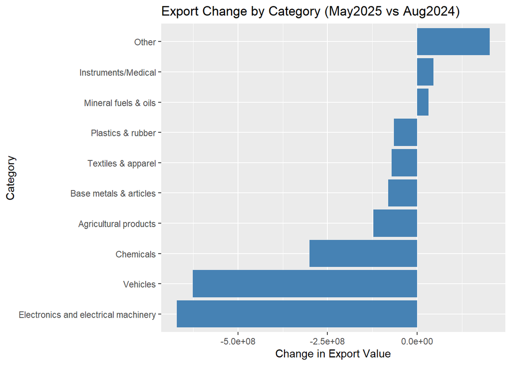

```r
ggplot(category_trends, aes(x = reorder(Category, Export_Change), y = Export_Change)) +
  geom_col(fill = "steelblue") +
  coord_flip() +
  labs(title = "Export Change by Category (May2025 vs Aug2024)", y = "Change in Export Value", x = "Category")
```

### **Observation:**

```r
# Show all commodities in the "Other" category
other_exports <- ohio_trend_data %>% filter(Category == "Other")

top_other_exports <- other_exports %>% arrange(desc(Export_Change))

top_other_exports %>%
  select(Commodity, Export_Value_Aug2024, Export_Value_May2025, Export_Change)
```

```
## # A tibble: 1,107 × 4
##    Commodity             Export_Value_Aug2024 Export_Value_May2025 Export_Change
##    <chr>                                <dbl>                <dbl>         <dbl>
##  1 CIVILIAN AIRCRAFT, E…            845894784           1053144864     207250080
##  2 AIRCRAFT, SPACECRAFT…            426317520            532688200     106370680
##  3 BOMB MINES OT AMMNTI…              1412255             22126341      20714086
##  4 ARMS AND AMMUNITION;…              3587603             24281156      20693553
##  5 BOMBS, GRENADES ETC;…              1587993             22130308      20542315
##  6 GLASS AND GLASSWARE               60197717             67055113       6857396
##  7 REAR-VIEW MIRRORS FO…             22809870             28962205       6152335
##  8 GLASS MIRRORS, FRAME…             22869435             29003661       6134226
##  9 CULTURED PEARLS, WOR…                    0              5750000       5750000
## 10 PEARLS, NATURAL OR C…                    0              5750000       5750000
## # ℹ 1,097 more rows
```

### **Observation:**

- CIVILIAN AIRCRAFT, ENGINES, AIRCRAFT, SPACECRAFT, GLASS AND GLASSWARE, PEARLS are so on are exported in May2025 compared in Aug2024

#### **Correlation b/w Export vs Imports(2024 and 2025)**

```r
corr_values <- c(
  cor(category_trends$Export_Change, category_trends$Import_Change, use = "complete.obs"),
  cor(category_trends$Total_Export_May2025, category_trends$Total_Import_May2025, use = "complete.obs"),
  cor(category_trends$Total_Export_Aug2024, category_trends$Total_Import_Aug2024, use = "complete.obs")
)
```

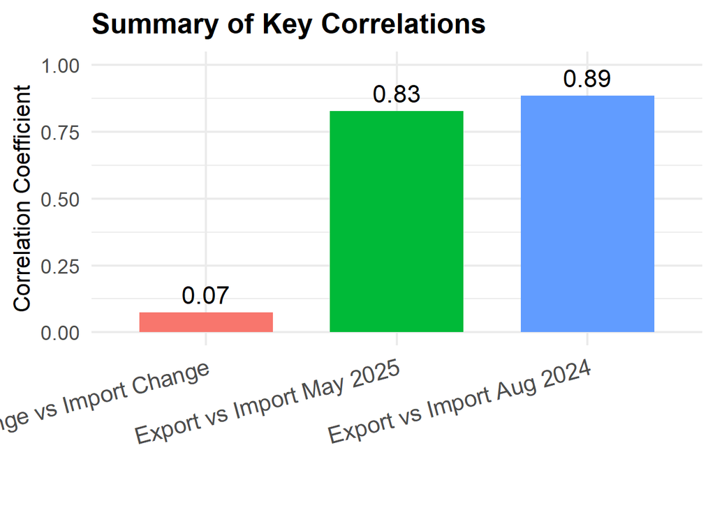

```r
library(ggplot2)

corr_df <- data.frame(
  Correlation = factor(c(
    "Export Change vs Import Change",
    "Export vs Import May 2025",
    "Export vs Import Aug 2024"
  ), levels = c(
    "Export Change vs Import Change",
    "Export vs Import May 2025",
    "Export vs Import Aug 2024"
  )),
  Value = corr_values
)

ggplot(corr_df, aes(x = Correlation, y = Value, fill = Correlation)) +
  geom_col(width = 0.7, show.legend = FALSE) +
  geom_text(aes(label = round(Value, 2)), vjust = -0.5, size = 6) +
  ylim(0, 1) +
  labs(title = "Summary of Key Correlations",
       y = "Correlation Coefficient",
       x = "") +
  theme_minimal(base_size = 18) + # Makes EVERYTHING bigger!
  theme(
    axis.text.x = element_text(angle = 15, hjust = 1, size = 16), # Bigger, readable
    plot.title  = element_text(size = 20, face = "bold"),
    axis.title.y= element_text(size = 16)
  )
```

### **Observation**: **Very low correlation (0.07) between Export Change and Import Change:** - Changes in what Ohio imports and exports are not closely related over the period.

**Strong positive correlation (0.83) between Export and Import values for May 2025:** - This suggests that Ohio’s biggest export sectors are also big importers, indicating two-way trade activity in those sectors.

**Even stronger positive correlation (0.89) between Export and Import values for August 2024:** - The relationship was even tighter for August 2024—again, sectors that exported a lot also imported a lot.

**Overall** - Category’s imports increased (or decreased) doesn’t mean exports for that category changed in the same way.

## **Global Trade Insights: UN Comtrade & OECD**

## **UN Comtrade Global Trade**

### **Which countries are the biggest players in global trade?**

#### **Setting Up and Authenticating US Comtrade Data Access**

```r
library(comtradr)
Sys.setenv(COMTRADE_PRIMARY = "6709dd04b6334fc29d6bd2ce171d1f9e
")
```

#### **Retrieving Global Annual Trade Data for Goods (Imports and Exports) from 2020 to 2023 Using comtradr Package**

```r
library(comtradr)

global_trade <- ct_get_data(
  type = "goods",
  frequency = "A",
  commodity_classification = "HS",
  commodity_code = "TOTAL",
  flow_direction = c("Import", "Export"),
  start_date = 2020,
  end_date = 2023,
  process = TRUE,
  tidy_cols = TRUE
)
```

#### **Cleaning and Summarizing Global Trade Data Columns**

```r
library(dplyr)

trimmed_trade_data <- global_trade %>%
  select(
    year = ref_year,
    reporter = reporter_desc,
    partner = partner_desc,
    flow = flow_desc,
    commodity_desc = cmd_desc,
    commodity_code = cmd_code,
    primary_value,
    fobvalue,
    cifvalue,
    net_wgt
  ) %>%
  mutate(across(
    c(primary_value, fobvalue, cifvalue, net_wgt),
    ~ as.numeric(as.character(.))
  ))

str(trimmed_trade_data)
```

```
## 'data.frame':    1290 obs. of  10 variables:
##  $ year          : int  2020 2020 2020 2020 2020 2020 2020 2020 2020 2020 ...
##  $ reporter      : chr  "Albania" "Albania" "Andorra" "Andorra" ...
##  $ partner       : chr  "World" "World" "World" "World" ...
##  $ flow          : chr  "Import" "Export" "Import" "Export" ...
##  $ commodity_desc: chr  "All Commodities" "All Commodities" "All Commodities" "All Commodities" ...
##  $ commodity_code: chr  "TOTAL" "TOTAL" "TOTAL" "TOTAL" ...
##  $ primary_value : num  5.41e+09 2.42e+09 1.49e+09 1.67e+08 9.34e+09 ...
##  $ fobvalue      : num  0.00 2.42e+09 NA 1.67e+08 NA ...
##  $ cifvalue      : num  5.41e+09 0.00 1.49e+09 NA 9.34e+09 ...
##  $ net_wgt       : num  0 0 0 0 0 0 NA 0 NA NA ...
##  - attr(*, "url")= chr "https://comtradeapi.un.org/data/v1/get/C/A/HS?cmdCode=TOTAL&flowCode=M%2CX&partnerCode=0&reporterCode=4%2C8%2C1"| __truncated__
##  - attr(*, "time")= POSIXct[1:1], format: "2025-08-01 07:28:29"
```

```r
head(trimmed_trade_data, 20)
```

```
##    year            reporter partner   flow  commodity_desc commodity_code
## 1  2020             Albania   World Import All Commodities          TOTAL
## 2  2020             Albania   World Export All Commodities          TOTAL
## 3  2020             Andorra   World Import All Commodities          TOTAL
## 4  2020             Andorra   World Export All Commodities          TOTAL
## 5  2020              Angola   World Import All Commodities          TOTAL
## 6  2020              Angola   World Export All Commodities          TOTAL
## 7  2020 Antigua and Barbuda   World Import All Commodities          TOTAL
## 8  2020 Antigua and Barbuda   World Export All Commodities          TOTAL
## 9  2020          Azerbaijan   World Import All Commodities          TOTAL
## 10 2020          Azerbaijan   World Export All Commodities          TOTAL
## 11 2020           Argentina   World Import All Commodities          TOTAL
## 12 2020           Argentina   World Export All Commodities          TOTAL
## 13 2020           Australia   World Import All Commodities          TOTAL
## 14 2020           Australia   World Export All Commodities          TOTAL
```

[output cut: 27 more lines]

```r
cat("Total rows:", nrow(trimmed_trade_data), "\n")
```

```
## Total rows: 1290
```

```r
cat("Rows with missing primary_value:", sum(is.na(trimmed_trade_data$primary_value)), "\n")
```

```
## Rows with missing primary_value: 0
```

```r
cat("Rows with missing fobvalue:", sum(is.na(trimmed_trade_data$fobvalue)), "\n")
```

```
## Rows with missing fobvalue: 378
```

```r
cat("Rows with missing cifvalue:", sum(is.na(trimmed_trade_data$cifvalue)), "\n")
```

```
## Rows with missing cifvalue: 470
```

```r
cat("Rows with missing net_wgt:", sum(is.na(trimmed_trade_data$net_wgt)), "\n")
```

```
## Rows with missing net_wgt: 364
```

#### **Replacing Missing Numeric Values in Trade Data with Zeros**

```r
clean_trade_data <- trimmed_trade_data %>%
  mutate(across(where(is.numeric), ~ replace_na(., 0)))
```

#### **1) Identifying and Visualizing Top 15 Importing Countries (2020–2023, All Commodities)**

```r
library(dplyr)
library(ggplot2)

# Filter for imports, summarize by reporter country
imports_by_reporter <- clean_trade_data %>%
  filter(flow == "Import") %>%
  group_by(reporter) %>%
  summarize(total_imports = sum(primary_value, na.rm = TRUE)) %>%
  arrange(desc(total_imports)) %>%
  slice_head(n = 15)

knitr::kable(imports_by_reporter)
```

| reporter | total_imports |
| --- | --- |
| USA | 1.187973e+13 |
| China | 1.002174e+13 |
| Germany | 5.656024e+12 |
| Japan | 3.058029e+12 |
| United Kingdom | 2.935700e+12 |
| France | 2.893194e+12 |
| China, Hong Kong SAR | 2.609541e+12 |
| Netherlands | 2.473813e+12 |
| Rep. of Korea | 2.456575e+12 |
| India | 2.343088e+12 |
| Italy | 2.329843e+12 |
| Mexico | 2.091078e+12 |
| Canada | 2.003838e+12 |
| Spain | 1.723897e+12 |
| Singapore | 1.632776e+12 |

### **Observation:**

- The USA has the highest total imports, followed by China.
- Both the USA and China have much higher import values compared to the rest.
- Germany, Japan, and the United Kingdom are the next largest importers.
- The import values decrease steadily after the top two countries.
- Singapore has the lowest total imports among the listed countries.

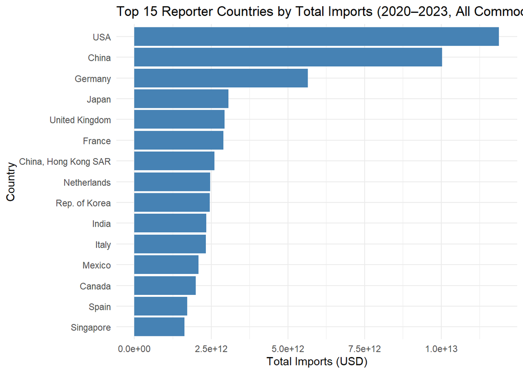

```r
ggplot(imports_by_reporter, aes(x = reorder(reporter, total_imports), y = total_imports)) +
  geom_col(fill = "steelblue") +
  coord_flip() +
  labs(
    title = "Top 15 Reporter Countries by Total Imports (2020–2023, All Commodities)",
    x = "Country",
    y = "Total Imports (USD)"
  ) +                    # <- Closing parenthesis and plus sign here!
  theme_minimal()
```

### **Observation:**

- The USA has the highest total imports from 2020 to 2023 among the top 15 countries.
- China is the second largest importer, with imports slightly less than the USA.
- Germany is the third largest importer, but with much lower imports than both the USA and China.
- Japan, United Kingdom, and France occupy the next ranks, each showing progressively lower import values.
- There is a noticeable gap between the top two countries (USA and China) and all others.
- The remaining countries (Hong Kong SAR, Netherlands, South Korea, India, Italy, Mexico, Canada, Spain, Singapore) have significantly lower import totals.

## **What are the top U.S. exports, and who is buying them?**

#### **Retrieving OECD Trade Data for U.S. Exports by Partner and Product Sector (2019 Onward)**

```r
library(rsdmx)
url <- "https://sdmx.oecd.org/public/rest/data/OECD.SDD.TPS,DSD_BIMTS@DF_BIMTS_HS2017_2D,1.0/USA.FRA+DEU+CHN+IND..C..HS17_85+HS17_84+HS17_30+HS17_39+_T.A.USD_EXC.?startPeriod=2019"

sdmx_data <- readSDMX(url)
```

#### **Cleaning and Preparing OECD Trade Data for Analysis**

```r
OECD_trade_data <- as.data.frame(sdmx_data)

# Save a CSV backup locally
write.csv(OECD_trade_data, "OECD_trade_data.csv", row.names = FALSE)

# Clean the data by selecting only needed columns
# (exporter, importer, product HS code, year, export value)
OECD_clean_data <- OECD_trade_data %>%
  dplyr::select(
    REF_AREA,          # Exporting country (e.g., USA)
    COUNTERPART_AREA,  # Importing partner country
    PRODUCT_HS,        # Product HS 2-digit code (commodity)
    obsTime,           # Observation year
    obsValue           # Export value in USD
  )

# Remove aggregate rows with product code "_T" or "TOTAL" that represent totals rather than specific products
OECD_clean_data <- OECD_clean_data %>%
  filter(!PRODUCT_HS %in% c("_T", "TOTAL"))

# Filter out zero or missing trade values for cleaner analysis
OECD_clean_data <- OECD_clean_data %>%
  filter(!is.na(obsValue) & obsValue > 0)

# Show the first rows of cleaned data to verify
head(OECD_clean_data)
```

```
##   REF_AREA COUNTERPART_AREA PRODUCT_HS obsTime  obsValue
## 1      USA              DEU    HS17_84    2022 12505.923
## 2      USA              FRA    HS17_84    2022  7930.509
## 3      USA              CHN    HS17_84    2019 15378.386
## 4      USA              DEU    HS17_84    2019 12215.033
## 5      USA              FRA    HS17_84    2019  8005.825
## 6      USA              IND    HS17_84    2019  3506.347
```

#### **1) Mapping Product HS Codes to Descriptions and Cleaning Product Labels in OECD Trade Data**

```r
product_lookup <- data.frame(
  PRODUCT_HS = c("HS17_30", "HS17_84", "HS17_85", "HS17_39", "_T", "TOTAL"),
  PRODUCT_DESC = c("Pharmaceuticals", "Machinery", "Electrical Machinery", "Plastics", "Total", "Total"),
  stringsAsFactors = FALSE
)


OECD_named_data <- OECD_clean_data %>%
  left_join(product_lookup, by = "PRODUCT_HS") %>%

    mutate(PRODUCT_HS = PRODUCT_DESC) %>%
  select(-PRODUCT_DESC)

knitr::kable(OECD_named_data)
```

| REF_AREA | COUNTERPART_AREA | PRODUCT_HS | obsTime | obsValue |
| --- | --- | --- | --- | --- |
| USA | DEU | Machinery | 2022 | 12505.9233 |
| USA | FRA | Machinery | 2022 | 7930.5091 |
| USA | CHN | Machinery | 2019 | 15378.3864 |
| USA | DEU | Machinery | 2019 | 12215.0327 |
| USA | FRA | Machinery | 2019 | 8005.8248 |
| USA | IND | Machinery | 2019 | 3506.3465 |
| USA | CHN | Machinery | 2019 | 15405.2296 |
| USA | DEU | Machinery | 2019 | 12379.7821 |
| USA | FRA | Machinery | 2019 | 8126.1857 |
| USA | IND | Plastics | 2019 | 1002.3750 |
| USA | CHN | Plastics | 2019 | 5534.3195 |
| USA | DEU | Plastics | 2019 | 1765.2097 |
| USA | FRA | Plastics | 2019 | 724.3693 |
| USA | IND | Pharmaceuticals | 2019 | 351.9544 |
| USA | CHN | Pharmaceuticals | 2019 | 4369.5594 |
| USA | DEU | Pharmaceuticals | 2019 | 7327.7558 |
| USA | FRA | Pharmaceuticals | 2019 | 2703.8023 |
| USA | IND | Electrical Machinery | 2019 | 1749.1829 |
| USA | CHN | Electrical Machinery | 2019 | 17123.5102 |
| USA | DEU | Electrical Machinery | 2019 | 6861.0980 |
| USA | FRA | Electrical Machinery | 2019 | 2883.6347 |
| USA | IND | Machinery | 2019 | 3397.8780 |
| USA | DEU | Pharmaceuticals | 2020 | 8304.7523 |
| USA | FRA | Pharmaceuticals | 2020 | 1147.4911 |
| USA | FRA | Plastics | 2020 | 552.5474 |
| USA | FRA | Electrical Machinery | 2020 | 1969.9939 |
| USA | FRA | Machinery | 2020 | 5670.8833 |
| USA | FRA | Machinery | 2020 | 5576.4333 |
| USA | FRA | Electrical Machinery | 2020 | 1906.7894 |
| USA | FRA | Pharmaceuticals | 2020 | 1045.9057 |

[output cut: 130 more lines]

#### **2) Identifying Top Importers by Product Sector in OECD Trade Data**

```r
library(dplyr)


OECD_named_data <- OECD_clean_data %>%
  left_join(product_lookup, by = "PRODUCT_HS") %>%
  mutate(PRODUCT_HS = PRODUCT_DESC) %>%
  select(-PRODUCT_DESC)

trade_summary <- OECD_named_data %>%
  group_by(obsTime, COUNTERPART_AREA, PRODUCT_HS) %>%
  summarise(total_export_usd = sum(obsValue, na.rm = TRUE), .groups = "drop")

country_lookup <- data.frame(
  COUNTERPART_AREA = c("CAN", "MEX", "DEU", "FRA", "CHN", "GBR", "NLD", "JPN", "ESP", "IND"),
  COUNTRY_NAME = c("Canada", "Mexico", "Germany", "France", "China", "United Kingdom", "Netherlands", "Japan", "Spain", "India"),
  stringsAsFactors = FALSE
)

trade_summary_named <- trade_summary %>%
  left_join(country_lookup, by = "COUNTERPART_AREA")

# Find top importers by product
top_importers <- trade_summary_named %>%
  group_by(PRODUCT_HS) %>%
  arrange(desc(total_export_usd)) %>%
  slice(1) %>%
  select(PRODUCT_HS, COUNTRY_NAME, total_export_usd)

knitr::kable(top_importers)
```

| PRODUCT_HS | COUNTRY_NAME | total_export_usd |
| --- | --- | --- |
| Electrical Machinery | China | 40881.94 |
| Machinery | China | 35495.85 |
| Pharmaceuticals | Germany | 19831.58 |
| Plastics | China | 15033.35 |

### **Observation:**

- Electrical Machinery is the top exported product sector to China, with export value around $40,882 (thousands or millions depending on units).
- Machinery follows, also exported heavily to China, around $35,496.
- Pharmaceuticals exports to Germany are significant, at about $19,832.
- Plastics exports to China are also notable, approximately $15,033.

#### **3) Visualizing Total U.S. Exports by Product Sector**

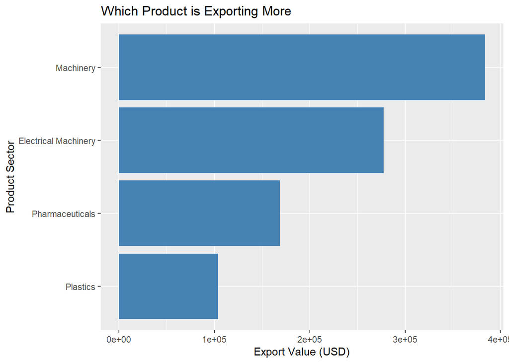

```r
exports_by_sector <- OECD_named_data %>%
  group_by(PRODUCT_HS) %>%
  summarise(total_export_usd = sum(obsValue, na.rm = TRUE)) %>%
  arrange(desc(total_export_usd))

ggplot(exports_by_sector, aes(x = total_export_usd, y = reorder(PRODUCT_HS, total_export_usd))) +
  geom_bar(stat = "identity", fill = "steelblue") +
  labs(title = "Which Product is Exporting More", x = "Export Value (USD)", y = "Product Sector")
```

#### **Loading and Prepare OECD Data**

```r
library(dplyr)
library(ggplot2)

product_lookup <- data.frame(
  PRODUCT_HS = c("HS17_30", "HS17_84", "HS17_85", "HS17_39", "_T", "TOTAL"),
  PRODUCT_DESC = c("Pharmaceuticals", "Machinery", "Electrical Machinery", "Plastics", "Total", "Total"),
  stringsAsFactors = FALSE
)

OECD_named_data <- OECD_clean_data %>%
  left_join(product_lookup, by = "PRODUCT_HS") %>%
  mutate(PRODUCT_HS = PRODUCT_DESC) %>%
  select(-PRODUCT_DESC) %>%
  filter(!PRODUCT_HS %in% c("Total"))  # Remove totals for analysis
```

#### **Aggregate Export Values by Product and Year**

```r
trade_summary <- OECD_named_data %>%
  group_by(obsTime, PRODUCT_HS) %>%
  summarise(total_export_usd = sum(obsValue, na.rm = TRUE), .groups = "drop")

# View summary
knitr::kable(trade_summary)
```

| obsTime | PRODUCT_HS | total_export_usd |
| --- | --- | --- |
| 2019 | Electrical Machinery | 57558.37 |
| 2019 | Machinery | 78414.67 |
| 2019 | Pharmaceuticals | 29609.72 |
| 2019 | Plastics | 18143.70 |
| 2020 | Electrical Machinery | 55588.13 |
| 2020 | Machinery | 66215.24 |
| 2020 | Pharmaceuticals | 29167.69 |
| 2020 | Plastics | 17971.33 |
| 2021 | Electrical Machinery | 60934.48 |
| 2021 | Machinery | 75415.28 |
| 2021 | Pharmaceuticals | 33594.39 |
| 2021 | Plastics | 20642.25 |
| 2022 | Electrical Machinery | 55878.26 |
| 2022 | Machinery | 80155.86 |
| 2022 | Pharmaceuticals | 36614.96 |
| 2022 | Plastics | 22920.52 |
| 2023 | Electrical Machinery | 47621.04 |
| 2023 | Machinery | 83559.35 |
| 2023 | Pharmaceuticals | 39906.46 |
| 2023 | Plastics | 24272.85 |

## **3. Visualize Export Trends Across Years by Product**

```
## `geom_line()`: Each group consists of only one observation.
## ℹ Do you need to adjust the group aesthetic?
```

[figure not shown]

```r
ggplot(trade_summary, aes(x = obsTime, y = total_export_usd, color = PRODUCT_HS)) +
  geom_line(size = 1.2) +
  geom_point() +
  labs(title = "U.S. Export Trends by Product Sector (2019-2022)",
       x = "Year", y = "Export Value (USD, thousands or millions as per data)",
       color = "Product Sector") +
  theme_minimal()
```

## **U.S. Census**

##### **1. We retrieved population and income information for every U.S. state**

- We found that you cannot judge a state’s income level just by looking at its population. Some smaller states actually have higher average incomes than much larger states.

##### **This can help the app by:**

- Making sure the app does not recommend markets or opportunities based only on population size.
- Instead, the app can highlight states or regions where people have more income to spend, which means better business opportunities no matter the population size.

##### **2. We extracted information on education levels, unemployment rates, poverty rates, and manufacturing employment for each state.**

- We found that states with higher education rates generally have higher incomes and lower poverty and unemployment.
- Places with high poverty or unemployment often have lower incomes, even if they have big populations or lots of manufacturing jobs.
- Manufacturing is important, but by itself, it doesn’t guarantee higher incomes the overall education and poverty levels matter more.

##### **This can help the app by:**

- Helping users spot states or regions that are more likely to succeed in trade because they have a skilled, educated population and less poverty
- Making the app’s advice more helpful and practical, because it takes into account the real social and economic background, not just surface numbers.

## **UN Comtrade**

##### **From the UN Comtrade global trade data (2020–2023)**

- we gathered yearly import and export values for all countries across all commodities.
- We identified the top 15 countries by total import value, finding that the USA and China lead by a wide margin, followed by countries like Germany, Japan, and the UK.

##### **This can help the app by:**

- The app can highlight the biggest global markets by import volume, showing users where demand is highest worldwide.
- This allows businesses to prioritize which countries to target for exports based on total import size, improving strategy and focus.

## **OECD Trade Data**

##### **From the OECD Import Data**

- Used filters based on Ohio’s export profile (such as picking the key countries and products relevant to Ohio) to pull focused export data.
- This allows us to see how U.S. exports perform in the same markets and product categories where Ohio is active making such analysis more directly useful for Ohio’s trade interests.

##### **This can help the app by:**

- The app can let users filter and view import/export data for just the countries and products that matter most to their industry or region (like Ohio).

## **Regression using Census data**

- We collected U.S. Census data for each state, including: population, education rate (percent with bachelor’s degree or higher), unemployment rate, poverty rate, share of manufacturing jobs, and median household income.
- We randomly split this set into a training group (to build our model) and a test group (to see how well the model works on new, unseen states).

##### **The results showed:**

- Education rate: States with more educated people tend to have much higher incomes.
- Poverty rate: More poverty means much lower incomes.
- Population and manufacturing: These didn’t actually help predict income very well.

##### **This can help the app by:**

- Businesses using the app can choose the best states or markets to focus on by looking at where people are well-educated and poverty is low, instead of just guessing based on how big the population or industry is.